# Minería de datos: PRA1 - Selección y preparación de un juego de datos

Autor: Santiago Domínguez\ Mayo 2020

1 Introducción

- 1.1 Presentación
- 1.2 Competencias
- 1.3 Objetivos
- 1.4 Descripción de la PRA a realizar
- 1.5 Recursos Básicos
- 1.6 Criterios de valoración
- 1.7 Formato y fecha de entrega PRA_1
- 1.8 Nota: Propiedad intelectual

2 Enunciado

3 Rúbrica

## 1 Introducción

## 1.1 Presentación

Esta práctica cubre de forma transversal la asignatura.

Las Prácticas 1 y 2 de la asignatura se plantean de una forma conjunta de modo que la Práctica 2 será continuación de la 1.

El objetivo global de las dos prácticas consiste en seleccionar uno o varios juegos de datos, realizar las tareas de preparación y análisis exploratorio con el objetivo de disponer de datos listos para aplicar algoritmos de clustering, asociación y clasificación.

## 1.2 Competencias

Las competencias que se trabajan en esta prueba son:

- Uso y aplicación de las TIC en el ámbito académico y profesional.
- Capacidad para innovar y generar nuevas ideas.
- Capacidad para evaluar soluciones tecnológicas y elaborar propuestas de proyectos teniendo en cuenta los recursos, las alternativas disponibles y las condiciones de mercado.
- Conocer las tecnologías de comunicaciones actuales y emergentes así como saberlas aplicar convenientemente para diseñar y desarrollar soluciones basadas en sistemas y tecnologías de la información.
- Aplicación de las técnicas específicas de ingeniería del software en las diferentes etapas del ciclo de vida de un proyecto.
- Capacidad para aplicar las técnicas específicas de tratamiento, almacenamiento y administración de datos.
- Capacidad para proponer y evaluar diferentes alternativas tecnológicas para resolver un problema concreto.

## 1.3 Objetivos

La correcta asimilación de todos los aspectos trabajados durante el semestre. En esta práctica abordamos un caso real de minería de datos donde tenemos que poner en juego todos los conceptos trabajados. Hay que trabajar todo el ciclo de vida del proyecto. Desde el objetivo del proyecto hasta la implementación del conocimiento encontrado pasando por la preparación, limpieza de los datos, conocimiento de los datos, generación del modelo, interpretación y evaluación.

## 1.4 Descripción de la PRA a realizar

## 1.5 Recursos Básicos

Material docente proporcionado por la UOC.

## 1.6 Criterios de valoración

**Ejercicios prácticos**

Para todas las PEC es necesario documentar en cada apartado del ejercicio práctico que se ha hecho y como se ha hecho.

## 1.7 Formato y fecha de entrega PRA_1

El formato de entrega es: usernameestudiant-PRA1.html y RMD \ Fecha de entrega: 06/05/2020 \ Se debe entregar la PRA_1 en el buzón de entregas del aula

## 1.8 Nota: Propiedad intelectual

A menudo es inevitable, al producir una obra multimedia, hacer uso de recursos creados por terceras personas. Es por lo tanto comprensible hacerlo en el marco de una práctica de los estudios de Informática, Multimedia y Telecomunicación de la UOC, siempre y cuando esto se documente claramente y no suponga plagio en la práctica.

Por lo tanto, al presentar una práctica que haga uso de recursos ajenos, se debe presentar junto con ella un documento en que se detallen todos ellos, especificando el nombre de cada recurso, su autor, el lugar donde se obtuvo y su estatus legal: si la obra esta protegida por el copyright o se acoge a alguna otra licencia de uso (Creative Commons, licencia GNU, GPL …). El estudiante deberá asegurarse de que la licencia no impide específicamente su uso en el marco de la práctica. En caso de no encontrar la información correspondiente tendrá que asumir que la obra esta protegida por copyright.

Deberéis, además, adjuntar los ficheros originales cuando las obras utilizadas sean digitales, y su código fuente si corresponde.

## 2 Enunciado

Todo estudio de minería debe nacer de una necesidad de alcanzar un objetivo que nos marcamos y que sólo podremos obtener a través de una colección de buenas prácticas basadas en la Minería de Datos.

El mundo de la minería de datos hemos de contemplar 3 ejes:

1. Uno de ellos es el profundo conocimiento que deberíamos tener del ámbito de los datos que estamos tratando al que intentamos dar respuestas.
2. El otro gran eje es sin duda las capacidades analíticas que seamos capaces de desplegar y en este sentido, las dos prácticas de esta asignatura pretenden que el estudiante realice un recorrido sólido por este segundo eje.
3. El tercer eje son los Datos. Llegar al objetivo debe concretarse con preguntas analíticas que a su vez sean viables responder a partir de los datos de que disponemos. La tarea de analizar los datos es sin duda importante, pero la tarea de identificarlos y obtenerlos es para un analista un reto permanente.

Como **primera** parte del estudio analítico que nos disponemos a realizar, se pide al estudiante que complete los siguientes pasos:

1. Seleccionar un juego de datos y justificar su elección. El juego de datos deberá tener capacidades para que se le puedan aplicar algoritmos supervisados, algoritmos no supervisados y reglas de asociación. Si el juego de datos no soporta los tres modelos se pueden elegir varios conjuntos de datos, derivar datos nuevos o fusionarlos con otros.
2. Realizar un análisis exploratorio del juego de datos seleccionado.
3. Realizar las tareas de limpieza y acondicionado necesarias para poder ser usado en procesos de creación de modelos de minería posteriores.
4. Realizar métodos de discretización
5. Aplicar un estudio PCA sobre el juego de datos. A pesar de no estar explicado en el material didáctico, se valorará si en lugar de PCA investigáis por vuestra cuenta y aplicáis SVD (Single Value Decomposition).

### 2.1 Breast Cancer Wisconsin Data set

El dataset elegido es una ver sión reducida de uno de los más conocidos en la comunidad. Es un dataset enfocado a la clasificación de tumores como malignos o benignos. Mi elección radica en que creo que este dataset es apto para todos los modelos de la PRAC2. Para el caso de la generación de reglas he escogido otro dataset. En este dataset probablemente se implementarán los siguientes modelos:

1. Kmeans. El cual está basado en distancia euclídea. Al tener las etiquetas en el dataset, será sencillo comprobar su eficacia.
2. DBSCAN. Este método de clustering se basa en la desidad de los datos, y no en la distancia entre ellos. También es no supervisado.
3. NN. Para el modelo supervisado implementaré una red neuronal. Estoy convencido de que será el modelo que mejor precisión muestre.

#### Carga y primer vistazo

Las columnas del dataset corresponden a:

- PatientID
- Clump Thickness
- Uniformity of Cell Size
- Uniformity of Cell Shape
- Marginal Adhesion
- Single Epithelial Cell Size
- Bare Nuclei
- Bland Chromatin
- Normal Nucleoli
- Mitoses

```python
import pandas as pd
df = pd.read_csv('wisconsin-cancer-dataset.csv',header=None,names=['PatientID','Clump Thickness','Uniformity of Cell Size','Uniformity of Cell Shape','Marginal Adhesion','Single Epithelial Cell Size','Bare Nuclei','Bland Chromatin','Normal Nucleoli','Mitoses','Output'])
df.head(10)
```

|  | PatientID | Clump Thickness | Uniformity of Cell Size | Uniformity of Cell Shape | Marginal Adhesion | Single Epithelial Cell Size | Bare Nuclei | Bland Chromatin | Normal Nucleoli | Mitoses | Output |
| --- | --- | --- | --- | --- | --- | --- | --- | --- | --- | --- | --- |
| 0 | 1000025 | 5 | 1 | 1 | 1 | 2 | 1 | 3 | 1 | 1 | 2 |
| 1 | 1002945 | 5 | 4 | 4 | 5 | 7 | 10 | 3 | 2 | 1 | 2 |
| 2 | 1015425 | 3 | 1 | 1 | 1 | 2 | 2 | 3 | 1 | 1 | 2 |
| 3 | 1016277 | 6 | 8 | 8 | 1 | 3 | 4 | 3 | 7 | 1 | 2 |
| 4 | 1017023 | 4 | 1 | 1 | 3 | 2 | 1 | 3 | 1 | 1 | 2 |
| 5 | 1017122 | 8 | 10 | 10 | 8 | 7 | 10 | 9 | 7 | 1 | 4 |
| 6 | 1018099 | 1 | 1 | 1 | 1 | 2 | 10 | 3 | 1 | 1 | 2 |
| 7 | 1018561 | 2 | 1 | 2 | 1 | 2 | 1 | 3 | 1 | 1 | 2 |
| 8 | 1033078 | 2 | 1 | 1 | 1 | 2 | 1 | 1 | 1 | 5 | 2 |
| 9 | 1033078 | 4 | 2 | 1 | 1 | 2 | 1 | 2 | 1 | 1 | 2 |

La columna de salida tiene los valores de 2 y 4 en lugar de 0 y 1. Es necesario remover la primera columna, el id del paciente no aporta información.

```python
df.describe()
```

|  | PatientID | Clump Thickness | Uniformity of Cell Size | Uniformity of Cell Shape | Marginal Adhesion | Single Epithelial Cell Size | Bland Chromatin | Normal Nucleoli | Mitoses | Output |
| --- | --- | --- | --- | --- | --- | --- | --- | --- | --- | --- |
| count | 6.990000e+02 | 699.000000 | 699.000000 | 699.000000 | 699.000000 | 699.000000 | 699.000000 | 699.000000 | 699.000000 | 699.000000 |
| mean | 1.071704e+06 | 4.417740 | 3.134478 | 3.207439 | 2.806867 | 3.216023 | 3.437768 | 2.866953 | 1.589413 | 2.689557 |
| std | 6.170957e+05 | 2.815741 | 3.051459 | 2.971913 | 2.855379 | 2.214300 | 2.438364 | 3.053634 | 1.715078 | 0.951273 |
| min | 6.163400e+04 | 1.000000 | 1.000000 | 1.000000 | 1.000000 | 1.000000 | 1.000000 | 1.000000 | 1.000000 | 2.000000 |
| 25% | 8.706885e+05 | 2.000000 | 1.000000 | 1.000000 | 1.000000 | 2.000000 | 2.000000 | 1.000000 | 1.000000 | 2.000000 |
| 50% | 1.171710e+06 | 4.000000 | 1.000000 | 1.000000 | 1.000000 | 2.000000 | 3.000000 | 1.000000 | 1.000000 | 2.000000 |
| 75% | 1.238298e+06 | 6.000000 | 5.000000 | 5.000000 | 4.000000 | 4.000000 | 5.000000 | 4.000000 | 1.000000 | 4.000000 |
| max | 1.345435e+07 | 10.000000 | 10.000000 | 10.000000 | 10.000000 | 10.000000 | 10.000000 | 10.000000 | 10.000000 | 4.000000 |

Vemos que todos los datos se comprenden entre 1 y 10. Igualmente regularizaremos tras la discretización.

```python
df.dtypes
```

```
PatientID                       int64
Clump Thickness                 int64
Uniformity of Cell Size         int64
Uniformity of Cell Shape        int64
Marginal Adhesion               int64
Single Epithelial Cell Size     int64
Bare Nuclei                    object
Bland Chromatin                 int64
Normal Nucleoli                 int64
Mitoses                         int64
Output                          int64
dtype: object
```

Vemos que hay algo raro en Bare Nuclei, no es de tipo numérico.

```python
df['Bare Nuclei'].value_counts()
```

```
1     402
10    132
2      30
5      30
3      28
8      21
4      19
?      16
9       9
7       8
6       4
Name: Bare Nuclei, dtype: int64
```

Removemos las 16 filas con valor nulo.

```python
df = df[df['Bare Nuclei'] != '?']
df=df.astype('int64')
df.dtypes
```

```
PatientID                      int64
Clump Thickness                int64
Uniformity of Cell Size        int64
Uniformity of Cell Shape       int64
Marginal Adhesion              int64
Single Epithelial Cell Size    int64
Bare Nuclei                    int64
Bland Chromatin                int64
Normal Nucleoli                int64
Mitoses                        int64
Output                         int64
dtype: object
```

#### Transformación

```python
#replazo el 2 por 0 y el 4 por 1 de la columna 10
df.iloc[:,10].replace(2, 0,inplace=True)
df.iloc[:,10].replace(4, 1,inplace=True)
#eliminamos las filas con valores vacíos o nulos
df.dropna(inplace=True)
#eliminamos la primera columna
df = df.drop('PatientID', 1)
df.head(10)
```

|  | Clump Thickness | Uniformity of Cell Size | Uniformity of Cell Shape | Marginal Adhesion | Single Epithelial Cell Size | Bare Nuclei | Bland Chromatin | Normal Nucleoli | Mitoses | Output |
| --- | --- | --- | --- | --- | --- | --- | --- | --- | --- | --- |
| 0 | 5 | 1 | 1 | 1 | 2 | 1 | 3 | 1 | 1 | 0 |
| 1 | 5 | 4 | 4 | 5 | 7 | 10 | 3 | 2 | 1 | 0 |
| 2 | 3 | 1 | 1 | 1 | 2 | 2 | 3 | 1 | 1 | 0 |
| 3 | 6 | 8 | 8 | 1 | 3 | 4 | 3 | 7 | 1 | 0 |
| 4 | 4 | 1 | 1 | 3 | 2 | 1 | 3 | 1 | 1 | 0 |
| 5 | 8 | 10 | 10 | 8 | 7 | 10 | 9 | 7 | 1 | 1 |
| 6 | 1 | 1 | 1 | 1 | 2 | 10 | 3 | 1 | 1 | 0 |
| 7 | 2 | 1 | 2 | 1 | 2 | 1 | 3 | 1 | 1 | 0 |
| 8 | 2 | 1 | 1 | 1 | 2 | 1 | 1 | 1 | 5 | 0 |
| 9 | 4 | 2 | 1 | 1 | 2 | 1 | 2 | 1 | 1 | 0 |

#### Análisis

Con el objetivo de discretizar alguna variable si es necesario, vamos a analizar los datos en comparación con la relación que tienen sobre la columna 10. Recordemos que dicha columna es en la que se indica si el tumor es maligno o benigno. Para hacer el notebook menos largo solo se muestran los atributos que se pueden discretizar.

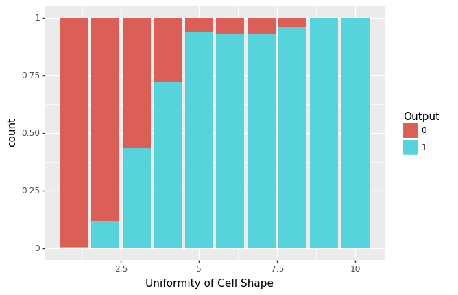

```python
df_plots = df.astype({'Output':'str'})
from plotnine import *
#Cell Shape
ggplot(df_plots) + geom_bar(aes(x='Uniformity of Cell Shape', fill='Output'),position="fill")
```

Los valores del 5 al 10 se pueden comprimir en 3. Dejando como resultado valores entre el 0 y 7.

```python
df['Uniformity of Cell Shape']=df['Uniformity of Cell Shape'].apply(lambda x: 5 if x==6 else(6 if x==8 or x==7 else(7 if x>8 else x)))
df['Uniformity of Cell Shape'].head(5)
```

```
0    1
1    4
2    1
3    6
4    1
Name: Uniformity of Cell Shape, dtype: int64
```

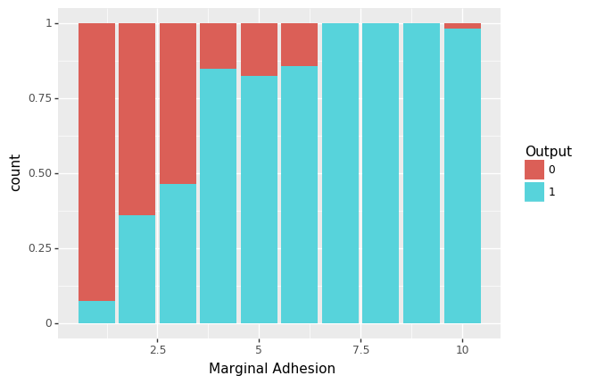

```python
#Marginal Adhesion
ggplot(df_plots) + geom_bar(aes(x='Marginal Adhesion', fill='Output'),position="fill")
```

Los valores 4,5,6 y 7,8 también presentan mucha similitud en relación con la salida.Reduciremos estos 4 valores a 2.

```python
df['Marginal Adhesion']=df['Marginal Adhesion'].apply(lambda x: 4 if x>4 and x<7 else(5 if x==8 or x==7 else(6 if x==9 else(7 if x==10 else x))))
df['Marginal Adhesion'].head(5)
```

```
0    1
1    4
2    1
3    1
4    3
Name: Marginal Adhesion, dtype: int64
```

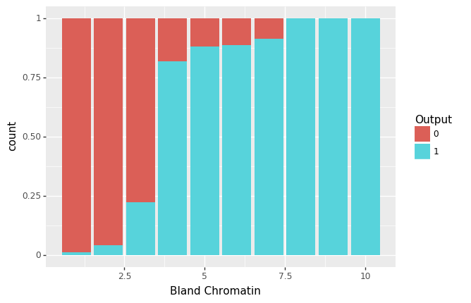

```python
#Bland Chromatin
ggplot(df_plots) + geom_bar(aes(x='Bland Chromatin', fill='Output'),position="fill")
```

En la columna Bland Chromatin, reducimos los 6 ultimos valores a 2.

```python
df['Bland Chromatin']=df['Bland Chromatin'].apply(lambda x: 5 if x>4 and x<8 else(6 if x>7 else x))
df['Bland Chromatin'].head(5)
```

```
0    3
1    3
2    3
3    3
4    3
Name: Bland Chromatin, dtype: int64
```

#### Normalización (min-max)

```python
column_maxes = df.iloc[:,0:9].max()
df_max = column_maxes.max()
normalized_df = df.iloc[:,0:9] / df_max
normalized_df['Output']=df['Output']
normalized_df
```

|  | Clump Thickness | Uniformity of Cell Size | Uniformity of Cell Shape | Marginal Adhesion | Single Epithelial Cell Size | Bare Nuclei | Bland Chromatin | Normal Nucleoli | Mitoses | Output |
| --- | --- | --- | --- | --- | --- | --- | --- | --- | --- | --- |
| 0 | 0.5 | 0.1 | 0.1 | 0.1 | 0.2 | 0.1 | 0.3 | 0.1 | 0.1 | 0 |
| 1 | 0.5 | 0.4 | 0.4 | 0.4 | 0.7 | 1.0 | 0.3 | 0.2 | 0.1 | 0 |
| 2 | 0.3 | 0.1 | 0.1 | 0.1 | 0.2 | 0.2 | 0.3 | 0.1 | 0.1 | 0 |
| 3 | 0.6 | 0.8 | 0.6 | 0.1 | 0.3 | 0.4 | 0.3 | 0.7 | 0.1 | 0 |
| 4 | 0.4 | 0.1 | 0.1 | 0.3 | 0.2 | 0.1 | 0.3 | 0.1 | 0.1 | 0 |
| ... | ... | ... | ... | ... | ... | ... | ... | ... | ... | ... |
| 694 | 0.3 | 0.1 | 0.1 | 0.1 | 0.3 | 0.2 | 0.1 | 0.1 | 0.1 | 0 |
| 695 | 0.2 | 0.1 | 0.1 | 0.1 | 0.2 | 0.1 | 0.1 | 0.1 | 0.1 | 0 |
| 696 | 0.5 | 1.0 | 0.7 | 0.3 | 0.7 | 0.3 | 0.6 | 1.0 | 0.2 | 1 |
| 697 | 0.4 | 0.8 | 0.5 | 0.4 | 0.3 | 0.4 | 0.6 | 0.6 | 0.1 | 1 |
| 698 | 0.4 | 0.8 | 0.6 | 0.4 | 0.4 | 0.5 | 0.6 | 0.4 | 0.1 | 1 |

683 rows × 10 columns

#### Nueva variable

Resulta evidente mirando las gráficas, que por lo general a mayor valor en las variables, más probabilidades de que la salida sea igual a 1.

```python
col_list= list(normalized_df)
col_list.remove('Output')
normalized_df['Suma'] = normalized_df[col_list].sum(axis=1)
normalized_df
```

|  | Clump Thickness | Uniformity of Cell Size | Uniformity of Cell Shape | Marginal Adhesion | Single Epithelial Cell Size | Bare Nuclei | Bland Chromatin | Normal Nucleoli | Mitoses | Output | Suma |
| --- | --- | --- | --- | --- | --- | --- | --- | --- | --- | --- | --- |
| 0 | 0.5 | 0.1 | 0.1 | 0.1 | 0.2 | 0.1 | 0.3 | 0.1 | 0.1 | 0 | 1.6 |
| 1 | 0.5 | 0.4 | 0.4 | 0.4 | 0.7 | 1.0 | 0.3 | 0.2 | 0.1 | 0 | 4.0 |
| 2 | 0.3 | 0.1 | 0.1 | 0.1 | 0.2 | 0.2 | 0.3 | 0.1 | 0.1 | 0 | 1.5 |
| 3 | 0.6 | 0.8 | 0.6 | 0.1 | 0.3 | 0.4 | 0.3 | 0.7 | 0.1 | 0 | 3.9 |
| 4 | 0.4 | 0.1 | 0.1 | 0.3 | 0.2 | 0.1 | 0.3 | 0.1 | 0.1 | 0 | 1.7 |
| ... | ... | ... | ... | ... | ... | ... | ... | ... | ... | ... | ... |
| 694 | 0.3 | 0.1 | 0.1 | 0.1 | 0.3 | 0.2 | 0.1 | 0.1 | 0.1 | 0 | 1.4 |
| 695 | 0.2 | 0.1 | 0.1 | 0.1 | 0.2 | 0.1 | 0.1 | 0.1 | 0.1 | 0 | 1.1 |
| 696 | 0.5 | 1.0 | 0.7 | 0.3 | 0.7 | 0.3 | 0.6 | 1.0 | 0.2 | 1 | 5.3 |
| 697 | 0.4 | 0.8 | 0.5 | 0.4 | 0.3 | 0.4 | 0.6 | 0.6 | 0.1 | 1 | 4.1 |
| 698 | 0.4 | 0.8 | 0.6 | 0.4 | 0.4 | 0.5 | 0.6 | 0.4 | 0.1 | 1 | 4.2 |

683 rows × 11 columns

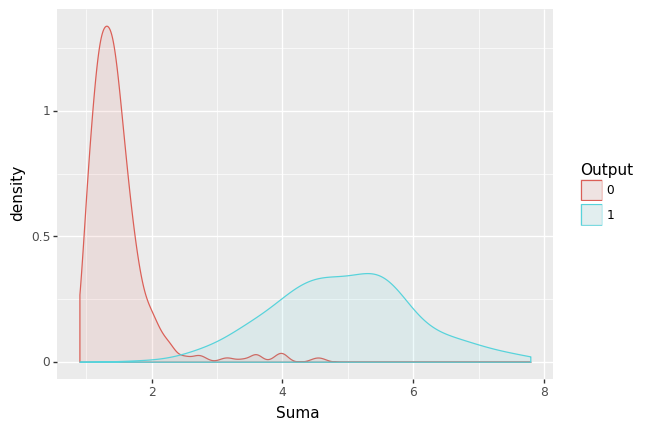

```python
df_plots = normalized_df.astype({'Output':'str'})
ggplot(df_plots, aes(x='Suma', color='Output', fill='Output')) + geom_density(alpha=0.1)
```

```python
#Volvemos a normalizar y cambiamos el orden de las columnas, dejando output la última.
normalized_df=normalized_df[['Clump Thickness','Uniformity of Cell Size','Uniformity of Cell Shape','Marginal Adhesion','Single Epithelial Cell Size','Bare Nuclei','Bland Chromatin','Normal Nucleoli','Mitoses','Suma','Output']]
column_maxes = normalized_df.iloc[:,0:10].max()
df_max = column_maxes.max()
normalized_df = normalized_df.iloc[:,0:10] / df_max
normalized_df['Output']=df['Output']
normalized_df
```

|  | Clump Thickness | Uniformity of Cell Size | Uniformity of Cell Shape | Marginal Adhesion | Single Epithelial Cell Size | Bare Nuclei | Bland Chromatin | Normal Nucleoli | Mitoses | Suma | Output |
| --- | --- | --- | --- | --- | --- | --- | --- | --- | --- | --- | --- |
| 0 | 0.064103 | 0.012821 | 0.012821 | 0.012821 | 0.025641 | 0.012821 | 0.038462 | 0.012821 | 0.012821 | 0.205128 | 0 |
| 1 | 0.064103 | 0.051282 | 0.051282 | 0.051282 | 0.089744 | 0.128205 | 0.038462 | 0.025641 | 0.012821 | 0.512821 | 0 |
| 2 | 0.038462 | 0.012821 | 0.012821 | 0.012821 | 0.025641 | 0.025641 | 0.038462 | 0.012821 | 0.012821 | 0.192308 | 0 |
| 3 | 0.076923 | 0.102564 | 0.076923 | 0.012821 | 0.038462 | 0.051282 | 0.038462 | 0.089744 | 0.012821 | 0.500000 | 0 |
| 4 | 0.051282 | 0.012821 | 0.012821 | 0.038462 | 0.025641 | 0.012821 | 0.038462 | 0.012821 | 0.012821 | 0.217949 | 0 |
| ... | ... | ... | ... | ... | ... | ... | ... | ... | ... | ... | ... |
| 694 | 0.038462 | 0.012821 | 0.012821 | 0.012821 | 0.038462 | 0.025641 | 0.012821 | 0.012821 | 0.012821 | 0.179487 | 0 |
| 695 | 0.025641 | 0.012821 | 0.012821 | 0.012821 | 0.025641 | 0.012821 | 0.012821 | 0.012821 | 0.012821 | 0.141026 | 0 |
| 696 | 0.064103 | 0.128205 | 0.089744 | 0.038462 | 0.089744 | 0.038462 | 0.076923 | 0.128205 | 0.025641 | 0.679487 | 1 |
| 697 | 0.051282 | 0.102564 | 0.064103 | 0.051282 | 0.038462 | 0.051282 | 0.076923 | 0.076923 | 0.012821 | 0.525641 | 1 |
| 698 | 0.051282 | 0.102564 | 0.076923 | 0.051282 | 0.051282 | 0.064103 | 0.076923 | 0.051282 | 0.012821 | 0.538462 | 1 |

683 rows × 11 columns

#### PCA

De cara a aplicar PCA previo a algún modelo (aún por decidir), prodecemos a realizar el análisis. Nótese que este paso puede ser de gran ayuda para visualizar los clusters.

Comenzamos estandarizando los datos. Media ~= 0 y varianza = 1.

```python
from sklearn.preprocessing import StandardScaler
x_std = StandardScaler().fit_transform(normalized_df.iloc[:,0:10])
```

Creamos una instanciación PCA

```python
from sklearn.decomposition import PCA
pca = PCA(n_components=10)
principalComponents = pca.fit_transform(x_std)
```

Mostramos las varianzas de los componentes del PCA.

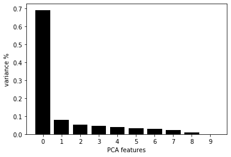

```python
from matplotlib import pyplot as plt
features = range(pca.n_components_)
plt.bar(features, pca.explained_variance_ratio_, color='black')
plt.xlabel('PCA features')
plt.ylabel('variance %')
plt.xticks(features)
plt.show()
```

Lo guardamos.

```python
PCA_components = pd.DataFrame(principalComponents)
```

Parece que el primer componente del PCA explica la mayoría de variación en los datos. En la práctica utilizaremos los dos primeros para mostrar más del 70% de la información total con solo dos componentes.

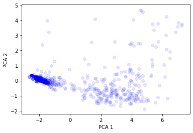

```python
plt.scatter(PCA_components[0], PCA_components[1],alpha=.1, color='blue')
plt.xlabel('PCA 1')
plt.ylabel('PCA 2')
```

Esta imagen nos muestra que la información de dataset puede ser claramente agrupada.

### 2.2 Market Basket Optimization

Este tipo de dtaset es ideal para implenetar reglas de asociación. Consiste en un archivo csv con múltiples compras.

#### Carga y Análisis

```python
df2 = pd.read_csv('Market_Basket_Optimisation.csv', header = None)
df2.shape
```

```
(7501, 20)
```

```python
df2.head()
```

|  | 0 | 1 | 2 | 3 | 4 | 5 | 6 | 7 | 8 | 9 | 10 | 11 | 12 | 13 | 14 | 15 | 16 | 17 | 18 | 19 |
| --- | --- | --- | --- | --- | --- | --- | --- | --- | --- | --- | --- | --- | --- | --- | --- | --- | --- | --- | --- | --- |
| 0 | shrimp | almonds | avocado | vegetables mix | green grapes | whole weat flour | yams | cottage cheese | energy drink | tomato juice | low fat yogurt | green tea | honey | salad | mineral water | salmon | antioxydant juice | frozen smoothie | spinach | olive oil |
| 1 | burgers | meatballs | eggs | NaN | NaN | NaN | NaN | NaN | NaN | NaN | NaN | NaN | NaN | NaN | NaN | NaN | NaN | NaN | NaN | NaN |
| 2 | chutney | NaN | NaN | NaN | NaN | NaN | NaN | NaN | NaN | NaN | NaN | NaN | NaN | NaN | NaN | NaN | NaN | NaN | NaN | NaN |
| 3 | turkey | avocado | NaN | NaN | NaN | NaN | NaN | NaN | NaN | NaN | NaN | NaN | NaN | NaN | NaN | NaN | NaN | NaN | NaN | NaN |
| 4 | mineral water | milk | energy bar | whole wheat rice | green tea | NaN | NaN | NaN | NaN | NaN | NaN | NaN | NaN | NaN | NaN | NaN | NaN | NaN | NaN | NaN |

```python
df2.describe()
```

|  | 0 | 1 | 2 | 3 | 4 | 5 | 6 | 7 | 8 | 9 | 10 | 11 | 12 | 13 | 14 | 15 | 16 | 17 | 18 | 19 |
| --- | --- | --- | --- | --- | --- | --- | --- | --- | --- | --- | --- | --- | --- | --- | --- | --- | --- | --- | --- | --- |
| count | 7501 | 5747 | 4389 | 3345 | 2529 | 1864 | 1369 | 981 | 654 | 395 | 256 | 154 | 87 | 47 | 25 | 8 | 4 | 4 | 3 | 1 |
| unique | 115 | 117 | 115 | 114 | 110 | 106 | 102 | 98 | 88 | 80 | 66 | 50 | 43 | 28 | 19 | 8 | 3 | 3 | 3 | 1 |
| top | mineral water | mineral water | mineral water | mineral water | green tea | french fries | green tea | green tea | green tea | green tea | low fat yogurt | green tea | green tea | green tea | magazines | magazines | frozen smoothie | protein bar | mayonnaise | olive oil |
| freq | 577 | 484 | 375 | 201 | 153 | 107 | 96 | 67 | 57 | 31 | 22 | 15 | 8 | 4 | 3 | 1 | 2 | 2 | 1 | 1 |

Es un dataset de 7501 compras con 20 columnas, lo cual indica que la compra más grande ha sido de 20 productos, pero obviamente hay muchos más productos. Por ejemplo, en la primera compra no hay hamburguesas y en la segunda es lo primero que aparece.

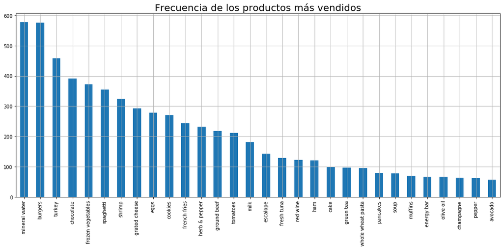

```python
import matplotlib.pyplot as plt

plt.rcParams['figure.figsize'] = (18, 7)
df2[0].value_counts().head(30).plot.bar()
plt.title('Frecuencia de los productos más vendidos', fontsize = 20)
plt.xticks(rotation = 90 )
plt.grid()
plt.show()
```

#### Transformación a transaction

Ahora procedemos a transformar los datos de cara a utilizar le modelo para generar las reglas de asociación.

Primero creamos una matriz con los objetos de cada compra

```python
import numpy as np
transactions = []
for i in range(0, 7501):
    transactions.append([str(df2.values[i,j]) for j in range(0, 20)])
transactions = np.array(transactions)
transactions.shape
```

```
(7501, 20)
```

```python
transactions[0:5]
```

```
array([['shrimp', 'almonds', 'avocado', 'vegetables mix', 'green grapes',
        'whole weat flour', 'yams', 'cottage cheese', 'energy drink',
        'tomato juice', 'low fat yogurt', 'green tea', 'honey', 'salad',
        'mineral water', 'salmon', 'antioxydant juice',
        'frozen smoothie', 'spinach', 'olive oil'],
       ['burgers', 'meatballs', 'eggs', 'nan', 'nan', 'nan', 'nan',
        'nan', 'nan', 'nan', 'nan', 'nan', 'nan', 'nan', 'nan', 'nan',
        'nan', 'nan', 'nan', 'nan'],
       ['chutney', 'nan', 'nan', 'nan', 'nan', 'nan', 'nan', 'nan',
        'nan', 'nan', 'nan', 'nan', 'nan', 'nan', 'nan', 'nan', 'nan',
        'nan', 'nan', 'nan'],
       ['turkey', 'avocado', 'nan', 'nan', 'nan', 'nan', 'nan', 'nan',
        'nan', 'nan', 'nan', 'nan', 'nan', 'nan', 'nan', 'nan', 'nan',
        'nan', 'nan', 'nan'],
       ['mineral water', 'milk', 'energy bar', 'whole wheat rice',
        'green tea', 'nan', 'nan', 'nan', 'nan', 'nan', 'nan', 'nan',
        'nan', 'nan', 'nan', 'nan', 'nan', 'nan', 'nan', 'nan']],
      dtype='<U20')
```

Utilizando el transaction encoder, se crea una columna para cada alimento, en cada compra se le asigna verdadero o falso a cada registro en función de si está o no en la compra.

```python
from mlxtend.preprocessing import TransactionEncoder

te = TransactionEncoder()
data = te.fit_transform(transactions)
data = pd.DataFrame(data, columns = te.columns_)

# getting the shape of the data
data.shape
```

```
(7501, 121)
```

```python
data.head()
```

|  | asparagus | almonds | antioxydant juice | asparagus | avocado | babies food | bacon | barbecue sauce | black tea | blueberries | ... | turkey | vegetables mix | water spray | white wine | whole weat flour | whole wheat pasta | whole wheat rice | yams | yogurt cake | zucchini |
| --- | --- | --- | --- | --- | --- | --- | --- | --- | --- | --- | --- | --- | --- | --- | --- | --- | --- | --- | --- | --- | --- |
| 0 | False | True | True | False | True | False | False | False | False | False | ... | False | True | False | False | True | False | False | True | False | False |
| 1 | False | False | False | False | False | False | False | False | False | False | ... | False | False | False | False | False | False | False | False | False | False |
| 2 | False | False | False | False | False | False | False | False | False | False | ... | False | False | False | False | False | False | False | False | False | False |
| 3 | False | False | False | False | True | False | False | False | False | False | ... | True | False | False | False | False | False | False | False | False | False |
| 4 | False | False | False | False | False | False | False | False | False | False | ... | False | False | False | False | False | False | True | False | False | False |

5 rows × 121 columns

#### Fuentes del ejercicio 2.1:

- Dataset: http://archive.ics.uci.edu/ml/datasets/breast+cancer+wisconsin+(diagnostic)
- https://stackoverflow.com/questions/18172851/deleting-dataframe-row-in-pandas-based-on-column-value
- https://pandas.pydata.org/pandas-docs/stable/reference/api/pandas.DataFrame.astype.html
- https://plotnine.readthedocs.io/en/stable/generated/plotnine.geoms.geom_bar.html#bar-chart
- https://plotnine.readthedocs.io/en/stable/generated/plotnine.geoms.geom_density.html#density-plot
- https://pandas.pydata.org/pandas-docs/stable/reference/api/pandas.DataFrame.apply.html
- https://stackoverflow.com/questions/25748683/pandas-sum-dataframe-rows-for-given-columns

#### Fuentes del ejercicio 2.2:

- Dataset: https://www.kaggle.com/roshansharma/market-basket-optimization
- https://www.kaggle.com/wilmeragskdd/tutorial-algorithms-association-rulesç
- https://towardsdatascience.com/pca-using-python-scikit-learn-e653f8989e60
- https://medium.com/@dmitriy.kavyazin/principal-component-analysis-and-k-means-clustering-to-visualize-a-high-dimensional-dataset-577b2a7a5fe2

## 3 Rúbrica

20%. Justificación razonada y completa de la elección del juego de datos donde se detalla el potencial analítico que se intuye y que se podrán crear los modelos solicitados. El estudiante deberá visitar los siguientes portales -o otros que desee- de datos abiertos para seleccionar su juego de datos:

- Datos.gob.es
- UCI Machine Learning
- Datasets Wikipedia
- Datos abierto Madrid
- Datos abiertos Barcelona
- London Datastore
- NYC OpenData

25%. Redactar de forma clara y completa la información extraída del análisis exploratorio. Distribuciones, correlaciones, anomalías, … ¿Qué se quiere obtener? Cómo se hace? ¿Qué se obtiene? Como se interpreta?

25%. Explicación clara de cualquier tarea de limpieza o acondicionado que se realiza. Justificando el motivo y mencionando las ventajas de la acción tomada.

25%. Realizar la discretización de los datos que lo requieran utilizando los diversos métodos vistos y justificando su elección.

5%. Se realiza un proceso de PCA o SVD donde se aprecia mediante explicaciones y comentarios que el estudiante entiende todos los pasos y se comenta extensamente el resultado final obtenido.